# Projet économétrie

Sarah Boukhari, Saadia Djambae, Ashani Gobalasamy, Daria Klimova, Sonia Ruzand

2025-02-17

## Importation de la base de donnée

## Construction de la base de données

## Introduction

L’achat de substances phytopharmaceutiques par les communes françaises en 2022 est-il influencé par des facteurs externes tel que la superficie agricole, les taxes ou encore leur impact potentiel sur la santé et l’environnement ?

## Description de la base de données

[output not shown]

Nombres d’observations : 5804 (représentant les commmunes françaises)  
Base de donnée : coupe transversalle

## Statistiques descriptives et representations graphiques

```
##  code_postal_acheteur quantite_substance      SAU             taxe
##  Length:5804          Min.   :  0.0000   Min.   :    0   Min.   :0.000
##  Class :character     1st Qu.:  0.5213   1st Qu.:  629   1st Qu.:3.233
##  Mode  :character     Median :  3.2749   Median : 2647   Median :3.517
##                       Mean   : 11.2919   Mean   : 4861   Mean   :3.381
##                       3rd Qu.: 12.3424   3rd Qu.: 7428   3rd Qu.:3.704
##                       Max.   :438.8664   Max.   :50145   Max.   :9.000
##                                          NA's   :45      NA's   :260
##    taxe_supp       impact_sante    log_quantite_substance
##  Min.   :0.0000   Min.   :0.0000   Min.   :   -Inf
##  1st Qu.:0.2174   1st Qu.:0.2627   1st Qu.:-0.6514
##  Median :0.2636   Median :0.2924   Median : 1.1863
##  Mean   :0.2618   Mean   :0.2824   Mean   :   -Inf
##  3rd Qu.:0.3145   3rd Qu.:0.3156   3rd Qu.: 2.5130
##  Max.   :1.5625   Max.   :1.0000   Max.   : 6.0842
##  NA's   :46       NA's   :291
```

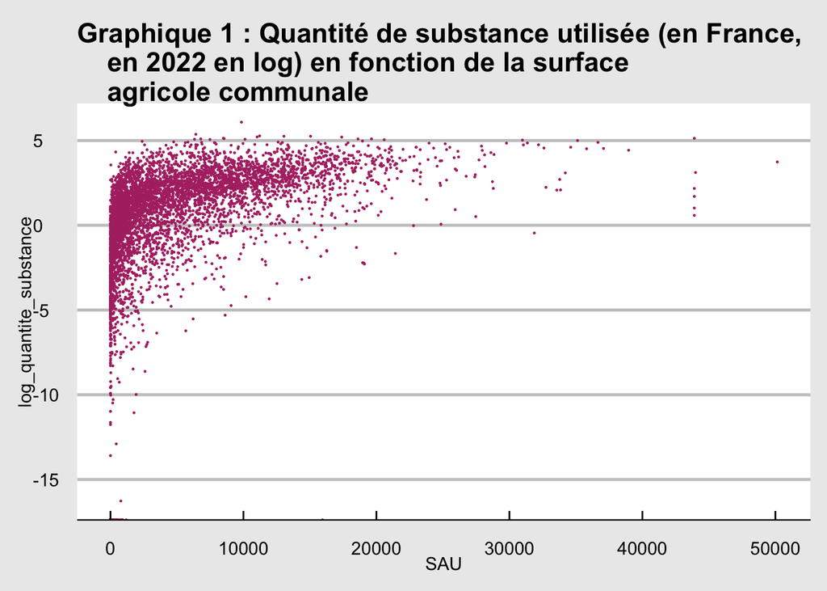

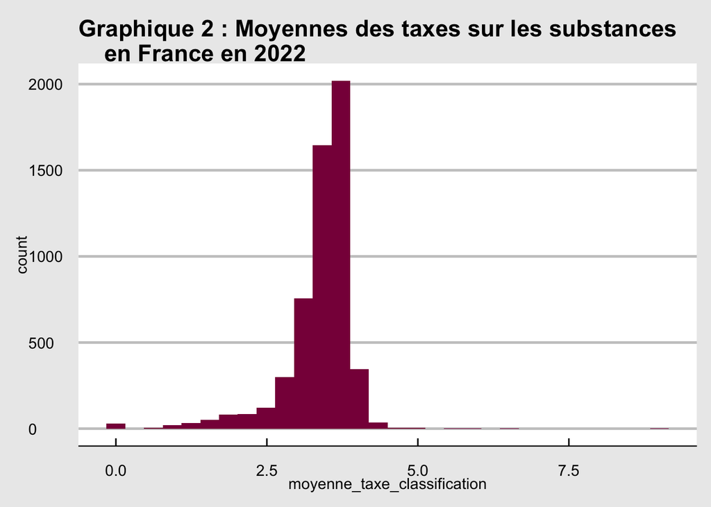

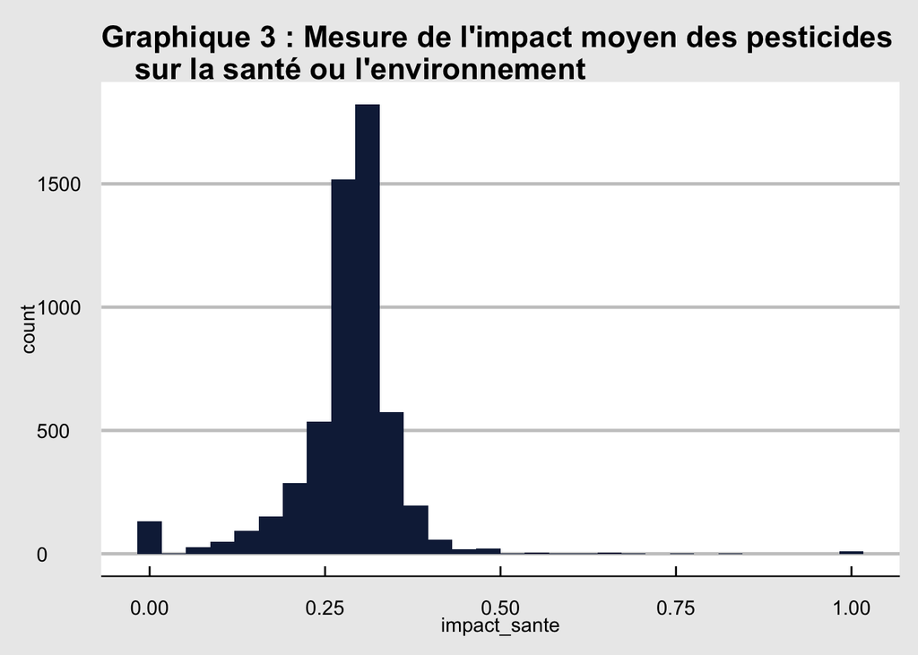

#### Interprétation Graphe 1 :

- SAU faible (0 à 10 000 ha) : La plupart des communes utilisent peu de substances, mais certaines en utilisent beaucoup plus que les autres.
- SAU moyenne (10 000 à 30 000 ha) : On observe encore beaucoup de différences entre les communes, avec une légère tendance à utiliser plus de substances quand la SAU augmente.
- SAU élevée (30 000 à 50 000 ha) : Il y a peu de communes dans cette catégorie, mais elles montrent aussi des niveaux très différents d’utilisation de substances.

## Modèle économique et économétrique :

L’équation à estimer :  
$quantite\_ substance_i = \beta_0 + \beta_1 \cdot SAU_i + \beta_2 \cdot taxe_i + \beta_3 \cdot taxe\_ supp_i + \beta_4 \cdot impact\_ sante_i + u_i$

Intuition et interprétation économique des paramètres :  
- $\beta_0$ : positif. Représente la quantité de substance achetée lorsque toutes les variables explicatives sont égales à zéro.  
- $\beta_1$ :de signe positif. Une augmentation de la surface argicole de 1ha devrait augmenter la quantité de substance achetée de $\beta_1$ tonnes  
- $\beta_2$ : de signe négatif. Une augmentation de la taxe liée à la classification des substances (toxiques ou polluantes) devrait réduire de $\beta_2$ tonnes la quantité achetée, car un coût plus élevé incite à substituer ou limiter l’usage des substances les plus taxées.  
- $\beta_3$ : de signe négatif. Une taxe supplémentaire sur certaines substances (mention “Exclusion” ou “Substitution”) devrait réduire encore davantage (de $\beta_3$ tonnes) les achats.  
- $\beta_4$ : de signe incertain, cela dépend si les acheteurs sont plus sensibles aux impacts sur leur santé ou sur l’environnement.

Le modèle économétrique et les MCO :

|  | (1) |
| --- | --- |
| (Intercept) | -7.651 |
|  | (1.787) |
| SAU | 0.002 |
|  | (0.000) |
| taxe | -1.162 |
|  | (0.645) |
| taxe_supp | 4.124 |
|  | (2.319) |
| impact_sante | 46.319 |
|  | (4.214) |
| Num.Obs. | 5513 |
| R2 | 0.262 |
| R2 Adj. | 0.261 |
| AIC | 47946.8 |
| BIC | 47986.5 |
| Log.Lik. | -23967.390 |
| F | 488.831 |
| RMSE | 18.70 |

```
##
## Call:
## lm(formula = quantite_substance ~ SAU + taxe + taxe_supp + impact_sante,
##     data = bdd_clean)
##
## Residuals:
##    Min     1Q Median     3Q    Max
## -83.49  -6.79  -2.79   1.58 414.51
##
## Coefficients:
##                Estimate Std. Error t value Pr(>|t|)
## (Intercept)  -7.651e+00  1.787e+00  -4.282 1.88e-05 ***
## SAU           1.831e-03  4.468e-05  40.975  < 2e-16 ***
## taxe         -1.162e+00  6.454e-01  -1.801   0.0718 .
## taxe_supp     4.124e+00  2.319e+00   1.778   0.0754 .
## impact_sante  4.632e+01  4.214e+00  10.991  < 2e-16 ***
## ---
## Signif. codes:  0 '***' 0.001 '**' 0.01 '*' 0.05 '.' 0.1 ' ' 1
##
## Residual standard error: 18.71 on 5508 degrees of freedom
##   (291 observations deleted due to missingness)
## Multiple R-squared:  0.262,  Adjusted R-squared:  0.2615
## F-statistic: 488.8 on 4 and 5508 DF,  p-value: < 2.2e-16
```

On a 26.1% (part de la variance) qui est expliqué par le modèle. De plus, le modèle est globalement significatif : les quatres variables explicatives, prises ensembles, ont un effet non nul sur la quantité achetée.

## Tests sur le premier modèle

#### Significativité (test de Student et Fisher)

Hypothèse testée au seuil de 5%:$H_0 : \beta_0 = 0 \quad \text{vs} \quad H_1 : \beta_0 \neq 0$

Règle de décision  
Si $|t_{\beta_0}| > t_{1-\alpha/2}(n - (k + 1))$, on rejette $H_0$

Application  
$t_{1-/2}(n - (k + 1)) = 1.96 $

-$|t_{\beta_0}| > t_{1-\alpha/2}(n - (k + 1))$,**on rejette** $H_0$: $\beta_0$ est significativement différent de 0

-$|t_{\beta_1}| > t_{1-\alpha/2}(n - (k + 1))$,**on rejette** $H_0$: $\beta_1$ est significativement différent de 0

-$|t_{\beta_4}| > t_{1-\alpha/2}(n - (k + 1))$, **on rejette** $H_0$: $\beta_4$ est significativement différent de 0

Significativité globale du modèle (test de Fisher) : Hypothèse testée au seuil de 5%: $H_0 : \beta_i = 0 \quad \text{vs} \quad H_1 : \beta_i \neq 0$ avec i = 1…,k

Règle de décision : Si $F > Fv1,v2$, on rejette $H_0$

Application : $F = 488.8$ $F v1,v2 = 2.37$, **on rejette** $H_0$: le modèle est globalement significatif.

#### Tests d’hétérocedasticité (BP et White)

La base de données utilisée étant une coupe transversale, il est possible que l’hypothèse H2 ne soit pas vérifiée. Cette hétéroscédasticité remet en question l’hypothèse de variance constante des résidus, ce qui peut affecter l’efficacité des estimateurs des moindres carrés ordinaires et biaiser les inférences statistiques. Afin de vérifier cette hypothèse, nous aurons recours aux tests de Breusch-Pagan et de White.

###### Test de BP :

On test $H_0 : \sigma_i^2 = \sigma_u^2 \quad \text{contre} \quad H_1 : \sigma_i^2 = h(Z_i, a), \quad \text{avec} \quad i = 1, \dots, N$ ### Étapes 1. Estimation du modèle par les MCO (Moindres Carrés Ordinaires). 2. Estimation des résidus : $\hat{u}_i^2$ 3. Régression auxiliaire sur les variables explicatives.

$\frac{\hat{u}_i^2}{\hat{\sigma}_u^2} = a_0 + a_1 Z_{1i} + a_2 Z_{2i} + \dots + a_p Z_{pi} + \eta_i \quad \text{(équation 2)}$

La statistique de test est la moiti´e de la SCE de la r´egression auxiliaire: $QBP = \frac{SCE}{2}$

```
##
##  studentized Breusch-Pagan test
##
## data:  mco_1
## BP = 143.17, df = 4, p-value < 2.2e-16
```

Si $QBP > \chi^2(p)$ : Rejeter $H_0$ → perturbations hétéroscédastiques.

Si $QBP < \chi^2(p)$ : Ne pas rejeter $H_0$ → perturbations homoscédastiques.

Application : p-value < 2.2e-16 , on rejette $H_0$, il y a présence d’hétéroscédasticité dans le modèle.

##### Test de White :

## Homoscédasticité

On teste :

$H_0 : \sigma_i^2 = \sigma_u^2 \quad \forall i \quad \text{vs.} \quad$ $H_1 : \exists \ (i, j),\ i \neq j : \sigma_i^2 \neq \sigma_u^2$

### Étapes :

1. Estimation du modèle par les MCO (Moindres Carrés Ordinaires).
2. Estimation des résidus : $\hat{u}_i^2$
3. Régression auxiliaire sur les variables explicatives.

$QW = N R^2 \approx \chi^2\left( \frac{(k+1)(k+2)}{2} - 1 \right)$

Règle de décision : **on rejette** $H_0$ si $Qw > χ²th$

```
## # A tibble: 1 × 5
##   statistic  p.value parameter method       alternative
##       <dbl>    <dbl>     <dbl> <chr>        <chr>
## 1      286. 1.23e-52        14 White's Test greater
```

D’après le test de White, la p-value étant inférieure à 0,05, nous rejetons l’hypothèse d’homoscédasticité, ce qui suggère que les perturbations sont hétéroscédastiques.

#### Correction hétéroscédasticité

L’écart-type robuste est une correction importante lorsque l’hypothèse d’homoscédasticité n’est plus valable. Il permet d’obtenir des inférences statistiques valides même en présence d’hétéroscédasticité inconnue. La méthode la plus connue pour corriger l’estimation de la matrice de variance-covariance est la correction de White.

La matrice corrigée proposée par White est donnée par :

$\widehat{V}(\beta_{\text{MCO}}) = (X^T X)^{-1} V (X^T X)^{-1}$ avec la correction $V = \sum_{i=1}^{N} \hat{u}_i^2 (X_i X_i^T)$

Grâce à cette correction, les écarts-types obtenus sont dits “robustes à l’hétéroscédasticité”, et permettent de réaliser des tests statistiques fiables malgré la violation de l’hypothèse d’homoscédasticité.

Après la correction avec les écarts-types robustes, on obtient les résultats suivants :

```
##
## t test of coefficients:
##
##                 Estimate  Std. Error t value  Pr(>|t|)
## (Intercept)  -7.6509e+00  1.2664e+00 -6.0413 1.629e-09 ***
## SAU           1.8306e-03  8.0935e-05 22.6178 < 2.2e-16 ***
## taxe         -1.1622e+00  7.1238e-01 -1.6314   0.10287
## taxe_supp     4.1237e+00  2.0195e+00  2.0419   0.04121 *
## impact_sante  4.6319e+01  5.8666e+00  7.8954 3.467e-15 ***
## ---
## Signif. codes:  0 '***' 0.001 '**' 0.01 '*' 0.05 '.' 0.1 ' ' 1
```

taxe_supp devient significatif à 5 % (p = 0.041), alors qu’il était à la limite (p = 0.075) sans robustesse.

taxe est encore moins significatif (p = 0.10), donc on ne peut pas conclure clairement sur son effet.

#### Test de la multicolinéarité :

On test:

```
##          SAU         taxe    taxe_supp impact_sante
##     1.035339     1.805727     1.028688     1.793638
```

Il n’y a pas de multicolinéarité entre les facteurs.

## Changement de modèle (modèle retenu)

On passe la quantité de substance en logarithme pour une intérpréttaion en pourcentage, ce qui nous semble être un peu plus logique. Le modèle devient une semi élasticité.

|  | (1) |
| --- | --- |
| (Intercept) | -5.535 |
|  | (0.170) |
| SAU | 0.000 |
|  | (0.000) |
| taxe | 1.032 |
|  | (0.061) |
| taxe_supp | 1.064 |
|  | (0.221) |
| impact_sante | 6.039 |
|  | (0.401) |
| Num.Obs. | 5513 |
| R2 | 0.420 |
| R2 Adj. | 0.420 |
| AIC | 32093.2 |
| BIC | 32132.9 |
| Log.Lik. | -10998.723 |
| RMSE | 1.78 |

```
##
## Call:
## lm(formula = log(quantite_substance) ~ SAU + taxe + taxe_supp +
##     impact_sante, data = bdd_clean)
##
## Residuals:
##      Min       1Q   Median       3Q      Max
## -22.7756  -0.7686   0.2163   1.0254   5.4215
##
## Coefficients:
##                Estimate Std. Error t value Pr(>|t|)
## (Intercept)  -5.535e+00  1.700e-01 -32.560  < 2e-16 ***
## SAU           1.862e-04  4.251e-06  43.818  < 2e-16 ***
## taxe          1.032e+00  6.141e-02  16.812  < 2e-16 ***
## taxe_supp     1.064e+00  2.206e-01   4.824 1.44e-06 ***
## impact_sante  6.039e+00  4.010e-01  15.062  < 2e-16 ***
## ---
## Signif. codes:  0 '***' 0.001 '**' 0.01 '*' 0.05 '.' 0.1 ' ' 1
##
## Residual standard error: 1.78 on 5508 degrees of freedom
##   (291 observations deleted due to missingness)
## Multiple R-squared:   0.42,  Adjusted R-squared:  0.4196
## F-statistic: 997.1 on 4 and 5508 DF,  p-value: < 2.2e-16
```

Ajout d’une contrainte : termes quadratiques sur taxe et taxe_supp car elles ne sont pas linéaire dans le modèle

```
##
## Call:
## lm(formula = log(quantite_substance) ~ SAU + taxe + I(taxe^2) +
##     taxe_supp + I(taxe_supp^2) + impact_sante, data = bdd_clean)
##
## Residuals:
##      Min       1Q   Median       3Q      Max
## -13.4494  -0.8024   0.1967   1.0137  12.1205
##
## Coefficients:
##                  Estimate Std. Error t value Pr(>|t|)
## (Intercept)    -1.156e+01  2.905e-01  -39.80   <2e-16 ***
## SAU             1.672e-04  3.895e-06   42.92   <2e-16 ***
## taxe            4.593e+00  1.871e-01   24.54   <2e-16 ***
## I(taxe^2)      -6.074e-01  2.953e-02  -20.57   <2e-16 ***
## taxe_supp       8.985e+00  4.272e-01   21.03   <2e-16 ***
## I(taxe_supp^2) -1.040e+01  4.667e-01  -22.28   <2e-16 ***
## impact_sante    5.846e+00  3.652e-01   16.01   <2e-16 ***
## ---
## Signif. codes:  0 '***' 0.001 '**' 0.01 '*' 0.05 '.' 0.1 ' ' 1
##
## Residual standard error: 1.615 on 5506 degrees of freedom
##   (291 observations deleted due to missingness)
## Multiple R-squared:  0.5229, Adjusted R-squared:  0.5224
## F-statistic:  1006 on 6 and 5506 DF,  p-value: < 2.2e-16
```

```r
as.data.frame(round(vcovHC(mco_2_quad, type = "HC1"), 5))
```

```
##                (Intercept) SAU     taxe I(taxe^2) taxe_supp I(taxe_supp^2)
## (Intercept)        0.21129   0 -0.14379   0.02226  -0.01365       -0.03485
## SAU                0.00000   0  0.00000   0.00000   0.00000        0.00000
## taxe              -0.14379   0  0.11438  -0.01822  -0.08771        0.14491
## I(taxe^2)          0.02226   0 -0.01822   0.00321   0.01557       -0.02300
## taxe_supp         -0.01365   0 -0.08771   0.01557   1.19721       -1.56471
## I(taxe_supp^2)    -0.03485   0  0.14491  -0.02300  -1.56471        2.31953
## impact_sante       0.08065   0 -0.06735  -0.00144  -0.22434        0.14009
##                impact_sante
## (Intercept)         0.08065
## SAU                 0.00000
## taxe               -0.06735
## I(taxe^2)          -0.00144
## taxe_supp          -0.22434
## I(taxe_supp^2)      0.14009
## impact_sante        0.76277
```

Equation à estimé du modèle 2 :  
$log\_quantite\_ substance_i = \beta_0 + \beta_1 \cdot SAU_i + \beta_2 \cdot taxe_i + \beta_3 \cdot (taxe)^2_i + \beta_4 \cdot taxe\_ supp_i + \beta_5 \cdot (taxe\_ supp)^2_i + \beta_6 \cdot impact\_ sante_i + u_i$

### Tests sur modèle 2

Test sur l’impact de la taxe:

L’impact de la taxe

```r
linearHypothesis(mco_2_quad, c("taxe = 0", "I(taxe^2) = 0"))
```

```
##
## Linear hypothesis test:
## taxe = 0
## I(taxe^2) = 0
##
## Model 1: restricted model
## Model 2: log(quantite_substance) ~ SAU + taxe + I(taxe^2) + taxe_supp +
##     I(taxe_supp^2) + impact_sante
##
##   Res.Df   RSS Df Sum of Sq      F    Pr(>F)
## 1   5508 16163
## 2   5506 14354  2    1809.6 347.09 < 2.2e-16 ***
## ---
## Signif. codes:  0 '***' 0.001 '**' 0.01 '*' 0.05 '.' 0.1 ' ' 1
```

L’impact de la taxe supplementaire:

```r
linearHypothesis(mco_2_quad, c("taxe_supp = 0", "I(taxe_supp^2) = 0"))
```

```
##
## Linear hypothesis test:
## taxe_supp = 0
## I(taxe_supp^2) = 0
##
## Model 1: restricted model
## Model 2: log(quantite_substance) ~ SAU + taxe + I(taxe^2) + taxe_supp +
##     I(taxe_supp^2) + impact_sante
##
##   Res.Df   RSS Df Sum of Sq      F    Pr(>F)
## 1   5508 15670
## 2   5506 14354  2    1316.3 252.47 < 2.2e-16 ***
## ---
## Signif. codes:  0 '***' 0.001 '**' 0.01 '*' 0.05 '.' 0.1 ' ' 1
```

Test de contrainte

```
## Analysis of Variance Table
##
## Model 1: log(quantite_substance) ~ SAU + taxe + taxe_supp + impact_sante
## Model 2: log(quantite_substance) ~ SAU + taxe + I(taxe^2) + taxe_supp +
##     I(taxe_supp^2) + impact_sante
##   Res.Df   RSS Df Sum of Sq      F    Pr(>F)
## 1   5508 17450
## 2   5506 14354  2    3096.4 593.88 < 2.2e-16 ***
## ---
## Signif. codes:  0 '***' 0.001 '**' 0.01 '*' 0.05 '.' 0.1 ' ' 1
```

Les termes taxe et taxe_supp au carré améliorent significativement le modèle, l’ajout des contraintes est justifié.

Test de l’hétéroscédasticité

```
##
##  studentized Breusch-Pagan test
##
## data:  mco_2_quad
## BP = 611.16, df = 6, p-value < 2.2e-16
```

Il y a de l’hétéroscédasticité, on la corrige :

|  | (1) |
| --- | --- |
| (Intercept) | -11.563 |
|  | (0.460) |
| SAU | 0.000 |
|  | (0.000) |
| taxe | 4.593 |
|  | (0.338) |
| I(taxe^2) | -0.607 |
|  | (0.057) |
| taxe_supp | 8.985 |
|  | (1.094) |
| I(taxe_supp^2) | -10.398 |
|  | (1.523) |
| impact_sante | 5.846 |
|  | (0.873) |
| Num.Obs. | 5513 |
| AIC | 31932.6 |
| BIC | 68354.0 |

```
##
## t test of coefficients:
##
##                   Estimate  Std. Error  t value  Pr(>|t|)
## (Intercept)    -1.1563e+01  4.5967e-01 -25.1543 < 2.2e-16 ***
## SAU             1.6719e-04  5.2589e-06  31.7919 < 2.2e-16 ***
## taxe            4.5927e+00  3.3820e-01  13.5801 < 2.2e-16 ***
## I(taxe^2)      -6.0740e-01  5.6672e-02 -10.7178 < 2.2e-16 ***
## taxe_supp       8.9847e+00  1.0942e+00   8.2114 2.699e-16 ***
## I(taxe_supp^2) -1.0398e+01  1.5230e+00  -6.8276 9.564e-12 ***
## impact_sante    5.8461e+00  8.7337e-01   6.6937 2.392e-11 ***
## ---
## Signif. codes:  0 '***' 0.001 '**' 0.01 '*' 0.05 '.' 0.1 ' ' 1
```

### Interpretation des estimations :

- $\beta_0$ : Lorsque la surface agricole de la commune est nulle, la taxe sur la classification et la taxe supplémentaire due aux mentions sont égales 0, et que la substance a un impact uniquement sur l’environnement (impact_sante = 0), alors la quantité achetée estimée est 0,000009537 tonnes.
- $\beta_1$ : Une utilisation de 1 hectare supplémentaire de la surface agricole est associée à une hausse de 0.0167 % de la quantité de substance.
- $\beta_2$ : Contre intuitif -> une augmentation d’un euro de la taxe est associée à une augmentation de 459.27% de la quantité de substance achetée.
- $\beta_3$ : Non-linéarité de l’effet de la taxe. La négativité de ce coefficient suggère qu’une augmentation supplémentaire de la taxe après un certain seuil réduira la quantité de substance.
- $\beta_4$ : Une augmentation d’un euro de la taxe supplémentaire conduit à une augmentation de 898.47% de la quantité de substance achetée.
- $\beta_5$ : L’impact de la taxe supplémentaire sur la quantité de substance a un effet de saturation (négatif après un certain seuil), comme pour le terme quadratique de la taxe standard.
- $\beta_6$ : Une augmentation d’une unité de l’impact sur la santé est associée à une augmentation de 584.61% de la quantité de substance achetée.

#### Test de Student :

Toutes les variables dans le modèle sont hautement significatives (p-value inférieure à 0.001), chaque coefficient est significativement différent de zéro ce qui signifie que les variables ont un effet statistiquement fiable sur la quantité de substance dans ce modèle.

#### Comparaison AIC et BIC des deux modèles :

Modèle 2 (mco_2_quadr)  
AIC : 31932.6  
BIC : 68354.0